# Founders Intravenous Self-Administration Data: Heritability and Plotting

Michael C. Saul (michael.saul [at] jax.org)

# 1 Background

## 1.1 Motivation

### 1.1.1 Purpose of analysis

This analysis is performed to process the intravenous self-administration data and calculate:

1. Heritability
2. Strain-by-sex means and standard errors for plotting

**These data were collected by the CSNA research assistants. Ultimate authorship of the resultant publications will be determined in discussion with Leona Gagnon.** The preprocessing script `IVSA_import_preprocess.Rmd` was used to filter the data to only those data requiring reporting.

### 1.1.2 Note about this analysis

The data have a floor effect (animals that took no cocaine) for infusions and a ceiling effect (animals that did not acquire self-administration) for sessions to acquisition. The appropriateness of a conventional linear model should be discussed with Vivek Philip. It’s possible that we should fit a Tobit regression.

# 2 Analysis

## 2.1 Setup

### 2.1.1 Working directory

All chunks will run in the working folder for this experiment.

```r
script_root_dir = "~/Downloads/founders_heritability/"
knitr::opts_knit$set(root.dir = script_root_dir)
```

Getting current date

```r
current_date = format(Sys.time(),"%Y-%m-%d")
```

### 2.1.2 R libraries

Calling R libraries necessary for this analysis.

```r
library("tidyverse")
```

```r
library("lubridate")
library("cowplot")
library("MASS")
library("ggbeeswarm")
```

## 2.2 Importing data

## 2.3 Importing and displaying raw intravenous self-administration data

Getting data from the filtering script and taking out the `DE_` part of the header

```r
IVSA_data = readRDS(paste(script_root_dir, "data/IVSA_data_preprocessed_2019-09-26.RDS", sep = ""))
colnames(IVSA_data) = gsub("^DE_","",colnames(IVSA_data))
row.names(IVSA_data) = as.character(IVSA_data$Subject)
```

Displaying raw data.

```r
IVSA_data$failed_aq = ifelse(IVSA_data$Exit_Reason == "IVSA Failed Acquisition", 2, 1)
IVSA_data
```

|  | Subject | Strain | Sex | birth_date_year | birth_date_month | birth_date_day | arrival_date_year | arrival_date_month | arrival_date_day | exit_date_year | exit_date_month | exit_date_day | Exit_Reason | DR_Inf_Total_1p0mgkg | AQ_SessionsToAcquisition | failed_aq |
| --- | --- | --- | --- | --- | --- | --- | --- | --- | --- | --- | --- | --- | --- | --- | --- | --- |
| 399 | 399 | C57BL/6J | M | 2017 | 2 | 21 | 2017 | 10 | 4 | 2017 | 6 | 29 | Finished Pipeline | 25.5000000 | 6 | 1 |
| 438 | 438 | NOD/ShiLtJ | M | 2017 | 2 | 21 | 2017 | 10 | 4 | 2017 | 6 | 14 | IVSA Failed Acquisition | 1.9166667 | 28 | 2 |
| 407 | 407 | NZO/HlLtJ | M | 2017 | 2 | 21 | 2017 | 10 | 4 | 2017 | 7 | 8 | Finished Pipeline | 23.5000000 | 8 | 1 |
| 408 | 408 | NZO/HlLtJ | M | 2017 | 2 | 21 | 2017 | 10 | 4 | 2017 | 6 | 27 | Finished Pipeline | 26.5000000 | 5 | 1 |
| 404 | 404 | NZO/HlLtJ | F | 2017 | 2 | 21 | 2017 | 10 | 4 | 2017 | 7 | 1 | Finished Pipeline | 22.5000000 | 5 | 1 |
| 429 | 429 | NOD/ShiLtJ | F | 2017 | 2 | 21 | 2017 | 10 | 4 | 2017 | 7 | 7 | Finished Pipeline | 24.5000000 | 16 | 1 |
| 453 | 453 | A/J | M | 2017 | 2 | 21 | 2017 | 10 | 4 | 2017 | 7 | 14 | Finished Pipeline | 20.0000000 | 12 | 1 |
| 393 | 393 | C57BL/6J | F | 2017 | 2 | 21 | 2017 | 10 | 4 | 2017 | 7 | 23 | Finished Pipeline | 30.5000000 | 27 | 1 |
| 414 | 414 | CAST/EiJ | M | 2017 | 2 | 21 | 2017 | 10 | 4 | 2017 | 6 | 28 | Finished Pipeline | 19.0000000 | 8 | 1 |
| 417 | 417 | 129S1/SvImJ | F | 2017 | 2 | 21 | 2017 | 10 | 4 | 2017 | 6 | 14 | IVSA Failed Acquisition | 0.0000000 | 28 | 2 |

[output cut: 207 more lines]

Getting founders strain key

```r
founders_key = readRDS("~/Desktop/cc_do_founders_key.RDS")
row.names(founders_key) = founders_key$strain
```

### 2.3.1 Fitting ANOVA model for intravenous self-administration dose-response 1.0 mg/kg data

Fitting the model with genetic background (strain), sex, and strain x sex interactions.

```r
anova(lm(DR_Inf_Total_1p0mgkg ~ Strain * Sex, data = IVSA_data))
```

|  | Df | Sum Sq | Mean Sq | F value | Pr(>F) |
| --- | --- | --- | --- | --- | --- |
| Strain | 7 | 4.792155e+04 | 6845.9358778 | 25.494654677 | 9.126543e-25 |
| Sex | 1 | 4.301723e-01 | 0.4301723 | 0.001601986 | 9.681131e-01 |
| Strain:Sex | 7 | 2.179419e+03 | 311.3456077 | 1.159468756 | 3.277717e-01 |
| Residuals | 201 | 5.397340e+04 | 268.5243619 | NA | NA |

Strain is the only significant factor here. Looking at the residuals of the simplest model with just this in it first.

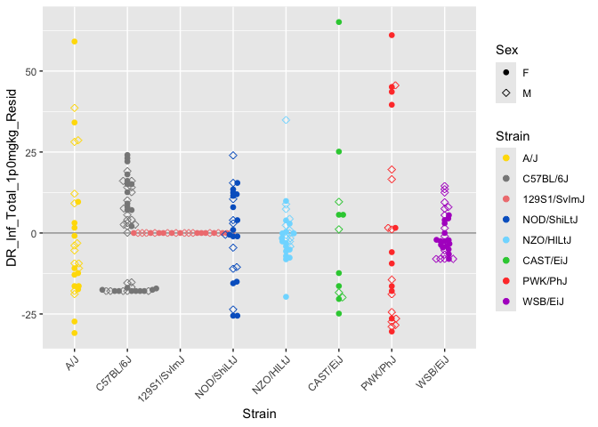

```r
IVSA_resid = IVSA_data
IVSA_resid$DR_Inf_Total_1p0mgkg_Resid = resid(lm(DR_Inf_Total_1p0mgkg ~ Strain, data = IVSA_resid))
IVSA_resid$Strain = factor(IVSA_resid$Strain,
                                           levels = founders_key$strain,
                                           ordered = TRUE)

ggplot(data = IVSA_resid, aes(x = Strain, y = DR_Inf_Total_1p0mgkg_Resid, color = Strain, shape = Sex)) +
  geom_hline(yintercept = 0, col = "#999999") +
  geom_beeswarm(size = 2) +
  scale_color_manual(values = founders_key$collaborative_cross_color_broman) +
  theme(axis.text.x = element_text(angle = 45, hjust = 1)) +
  scale_shape_manual(values = c(16,23))
```

The residuals indicate heteroscedasticity. 129 doesn’t respond, so not worrying about those points. *NOTE: Heritability should be calculated both with 129 and without to prevent upward bias.* However, the PWK residuals appear to be at least 2.5-fold greater in magnitude than the WSB residuals. Doing a Box-Cox to see if a response variable transformation is merited.

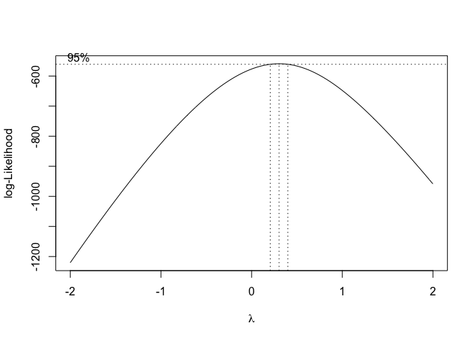

```r
boxcox(lm((DR_Inf_Total_1p0mgkg + 1) ~ Strain, data = IVSA_resid))
```

The Box-Cox log-likelihood is highest at about 1/3, which implies that a cube root transform will be advantageous.

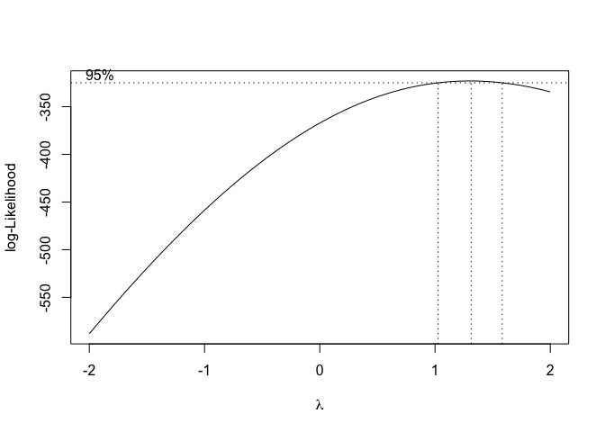

```r
boxcox(lm(1 + (DR_Inf_Total_1p0mgkg ^ (1/3)) ~ Strain, data = IVSA_resid))
```

The Box-Cox log-likelihood is centered closer to 1. Plotting residuals.

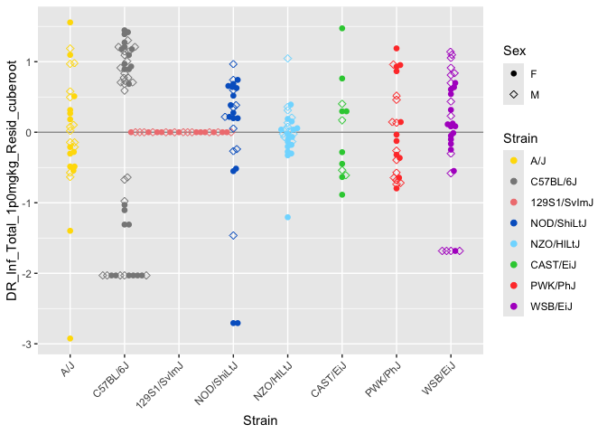

```r
IVSA_resid$DR_Inf_Total_1p0mgkg_Resid_cuberoot = resid(lm((DR_Inf_Total_1p0mgkg ^ (1/3)) ~ Strain, data = IVSA_resid))

ggplot(data = IVSA_resid, aes(x = Strain, y = DR_Inf_Total_1p0mgkg_Resid_cuberoot, color = Strain, shape = Sex)) +
  geom_hline(yintercept = 0, col = "#999999") +
  geom_beeswarm(size = 2) +
  scale_color_manual(values = founders_key$collaborative_cross_color_broman) +
  theme(axis.text.x = element_text(angle = 45, hjust = 1)) +
  scale_shape_manual(values = c(16,23))
```

These residuals are better. Doing model selection based upon this transform.

```r
AICs = c()
AICs["AIC_inter"] = AIC(lm((DR_Inf_Total_1p0mgkg ^ (1/3))  ~ Strain + Sex + Strain:Sex, data = IVSA_data))
AICs["AIC_nointer"] = AIC(lm((DR_Inf_Total_1p0mgkg ^ (1/3))  ~ Strain + Sex, data = IVSA_data))
AICs["AIC_nosex"] = AIC(lm((DR_Inf_Total_1p0mgkg ^ (1/3))  ~ Strain, data = IVSA_data))
AICs["AIC_nostrain"] = AIC(lm((DR_Inf_Total_1p0mgkg ^ (1/3))  ~ 1, data = IVSA_data))

AICs
```

```
##    AIC_inter  AIC_nointer    AIC_nosex AIC_nostrain
##     590.5887     579.8956     578.6484     745.4925
```

```r
BICs = c()
BICs["BIC_inter"] = BIC(lm((DR_Inf_Total_1p0mgkg ^ (1/3))  ~ Strain + Sex + Strain:Sex, data = IVSA_data))
BICs["BIC_nointer"] = BIC(lm((DR_Inf_Total_1p0mgkg ^ (1/3))  ~ Strain + Sex, data = IVSA_data))
BICs["BIC_nosex"] = BIC(lm((DR_Inf_Total_1p0mgkg ^ (1/3))  ~ Strain, data = IVSA_data))
BICs["BIC_nostrain"] = BIC(lm((DR_Inf_Total_1p0mgkg ^ (1/3))  ~ 1, data = IVSA_data))

BICs
```

```
##    BIC_inter  BIC_nointer    BIC_nosex BIC_nostrain
##     648.0469     613.6946     609.0675     752.2523
```

The best model for heritability according to both AIC and BIC contain only strain with no sex and strain:sex interaction factors. The residuals for this model have been plotted above. Showing the ANOVA table for this model.

```r
anova(lm((DR_Inf_Total_1p0mgkg ^ (1/3))  ~ Strain, data = IVSA_data))
```

|  | Df | Sum Sq | Mean Sq | F value | Pr(>F) |
| --- | --- | --- | --- | --- | --- |
| Strain | 7 | 218.9528 | 31.2789699 | 38.84685 | 1.291252e-34 |
| Residuals | 209 | 168.2841 | 0.8051869 | NA | NA |

```r
anova(lm((DR_Inf_Total_1p0mgkg ^ (1/3))  ~ Strain, data = IVSA_data))$`Pr(>F)`[1]
```

```
## [1] 1.291252e-34
```

This ANOVA model will be used for downstream heritability calculations.

### 2.3.2 Calculating heritability for dose-response 1.0 mg/kg data

Calculating heritability using the ANOVA table from the best fitting model. Using the following equation:

$h^2=\displaystyle{{MS_{strain}}-{MS_{resid}}\over{MS_{strain} + (n_{mean} - 1) * MS_{resid}}}$

where $MS_{strain}$ is the mean square of the strain differences, $MS_{resid}$ is the mean square of the residuals, and $n_{mean}$ is the mean sample size of a strain. Starting with the IVSA data that include 129.

```r
h2_strainanova <- function(msgenetics, mserror, n) {
  return((msgenetics - mserror) / (msgenetics + (n - 1) * mserror))
}

mean_n = nrow(IVSA_data) / length(unique(IVSA_data$Strain))
anova_DR_1p0mgkg = anova(lm((DR_Inf_Total_1p0mgkg ^ (1/3))  ~ Strain, data = IVSA_data))
anova_DR_1p0mgkg_df = as.data.frame(anova_DR_1p0mgkg)

h2_DR_1p0mgkg_df = h2_strainanova(anova_DR_1p0mgkg_df["Strain","Mean Sq"],
                                  anova_DR_1p0mgkg_df["Residuals","Mean Sq"],
                                  mean_n)
h2_DR_1p0mgkg_df
```

```
## [1] 0.5825115
```

This heritability of 0.58 is higher than previous estimates. It should be noted that this is reasonably close to the estimate of cocaine use disorder heritability that’s observed in humans.

Calculating the heritability without 129.

```r
IVSA_data_no_129 = IVSA_data[which(IVSA_data$Strain != "129S1/SvImJ"),]
IVSA_data_no_129$Strain = as.character(IVSA_data_no_129$Strain)
mean_n = nrow(IVSA_data_no_129) / length(unique(IVSA_data_no_129$Strain))
anova_DR_1p0mgkg_no_129 = anova(lm((DR_Inf_Total_1p0mgkg ^ (1/3))  ~ Strain, data = IVSA_data_no_129))
anova_DR_1p0mgkg_no_129_df = as.data.frame(anova_DR_1p0mgkg_no_129)
h2_DR_1p0mgkg_df_no_129 = h2_strainanova(anova_DR_1p0mgkg_no_129_df["Strain","Mean Sq"],
                                         anova_DR_1p0mgkg_no_129_df["Residuals","Mean Sq"],
                                         mean_n)
h2_DR_1p0mgkg_df_no_129
```

```
## [1] 0.3246075
```

129 appreciably drives the heritability; the number of 0.32 is a significant drop.

### 2.3.3 Plotting strain x sex means for total infusions at FR1 1.0 mg/kg

Plotting the strain:sex information for these data. The calculations will be back-transformed.

```r
IVSA_DR_1p0mgkg_summary = IVSA_data %>%
  group_by(Strain, Sex) %>%
  summarize(Strain_Sex_mean = mean((DR_Inf_Total_1p0mgkg ^ (1/3)), na.rm = TRUE),
            Strain_Sex_sem = sd((DR_Inf_Total_1p0mgkg ^ (1/3)), na.rm = TRUE) / length(which(!is.na((DR_Inf_Total_1p0mgkg ^ (1/3))))),
            Strain_Sex_n = length(which(!is.na(log10(AQ_SessionsToAcquisition))))) %>%
  mutate(Strain_Sex = paste(Strain, gsub("^([MF]).*$", "\\1", Sex), sep = " "),
         Strain_Sex_backmean = Strain_Sex_mean ^ 3,
         Strain_Sex_ul = (Strain_Sex_mean + Strain_Sex_sem) ^ 3,
         Strain_Sex_ll = (Strain_Sex_mean - Strain_Sex_sem) ^ 3)
```

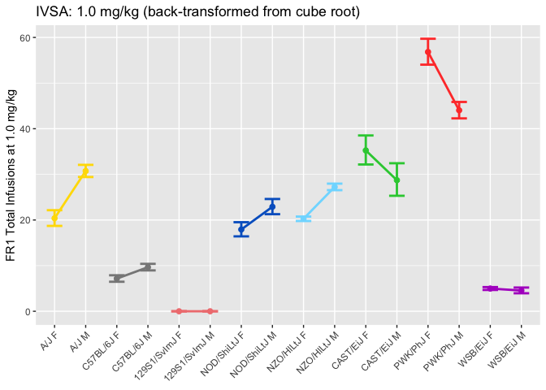

```r
IVSA_DR_1p0mgkg_summary = as.data.frame(IVSA_DR_1p0mgkg_summary)
IVSA_DR_1p0mgkg_summary$Strain_Sex = factor(IVSA_DR_1p0mgkg_summary$Strain_Sex,
                                                levels = paste(rep(founders_key$strain, each = 2), rep(c(" F", " M"), times = 8), sep = ""),
                                                ordered = TRUE)
IVSA_DR_1p0mgkg_summary$Strain = factor(IVSA_DR_1p0mgkg_summary$Strain,
                                            levels = founders_key$strain,
                                            ordered = TRUE)

founders_IVSA_DR_1p0mgkg_plot = ggplot(data = IVSA_DR_1p0mgkg_summary, aes(x = Strain_Sex, y = Strain_Sex_backmean, color = Strain, group = Strain)) +
  geom_line(size = 1) +
  geom_point(size = 2) +
  geom_errorbar(aes(ymin = Strain_Sex_ll, ymax = Strain_Sex_ul), width = 0.5, size = 1) +
  scale_color_manual(values = founders_key$collaborative_cross_color_broman) +
  theme(axis.text.x = element_text(angle = 45, hjust = 1), legend.position="none") +
  xlab(NULL) +
  ylab("FR1 Total Infusions at 1.0 mg/kg") +
  ggtitle("IVSA: 1.0 mg/kg (back-transformed from cube root)")
founders_IVSA_DR_1p0mgkg_plot
```

Saving plot

```r
saveRDS(founders_IVSA_DR_1p0mgkg_plot, "./output/founders_IVSA_DR_1p0mgkg_plot_sex_plot.RDS")
```

### 2.3.4 Fitting ANOVA model for intravenous sessions to acquisition for self-administraion at 1.0 mg/kg

Fitting the model with genetic background (strain), sex, and strain x sex interactions.

```r
anova(lm(AQ_SessionsToAcquisition ~ Strain * Sex, data = IVSA_data))
```

|  | Df | Sum Sq | Mean Sq | F value | Pr(>F) |
| --- | --- | --- | --- | --- | --- |
| Strain | 7 | 9486.0300 | 1355.14715 | 25.5825654 | 7.789657e-25 |
| Sex | 1 | 210.8894 | 210.88935 | 3.9811844 | 4.736172e-02 |
| Strain:Sex | 7 | 114.3691 | 16.33844 | 0.3084383 | 9.495763e-01 |
| Residuals | 201 | 10647.2737 | 52.97151 | NA | NA |

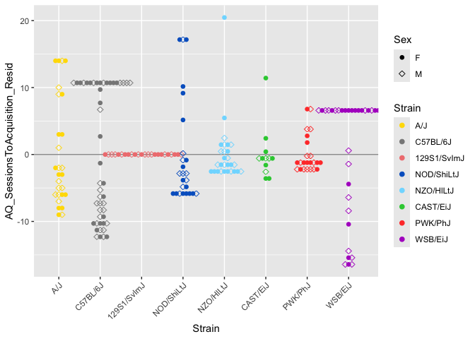

```r
IVSA_resid$AQ_SessionsToAcquisition_Resid = resid(lm(AQ_SessionsToAcquisition ~ Strain, data = IVSA_resid))

ggplot(data = IVSA_resid, aes(x = Strain, y = AQ_SessionsToAcquisition_Resid, color = Strain, shape = Sex)) +
  geom_hline(yintercept = 0, col = "#999999") +
  geom_beeswarm(size = 2) +
  scale_color_manual(values = founders_key$collaborative_cross_color_broman) +
  theme(axis.text.x = element_text(angle = 45, hjust = 1)) +
  scale_shape_manual(values = c(16,23))
```

This fit doesn’t look good. Trying Box-Cox to see if a response variable transform may be merited.

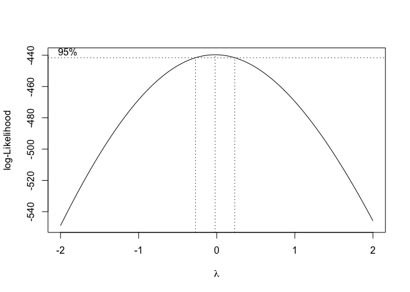

```r
boxcox(lm(AQ_SessionsToAcquisition ~ Strain, data = IVSA_resid))
```

The log-likelihood centered at 0 implies that a log-transform may help with the non-normal residuals.

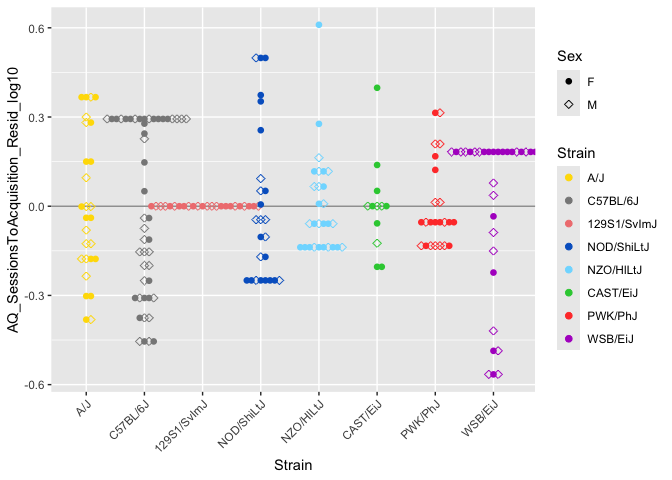

```r
IVSA_resid$AQ_SessionsToAcquisition_Resid_log10 = resid(lm(log10(AQ_SessionsToAcquisition) ~ Strain, data = IVSA_resid))

ggplot(data = IVSA_resid, aes(x = Strain, y = AQ_SessionsToAcquisition_Resid_log10, color = Strain, shape = Sex)) +
  geom_hline(yintercept = 0, col = "#999999") +
  geom_beeswarm(size = 2) +
  scale_color_manual(values = founders_key$collaborative_cross_color_broman) +
  theme(axis.text.x = element_text(angle = 45, hjust = 1)) +
  scale_shape_manual(values = c(16,23))
```

This looks a little better. Trying Box-Cox to see if the log-likelihood is centered at 1 with the transformed data.

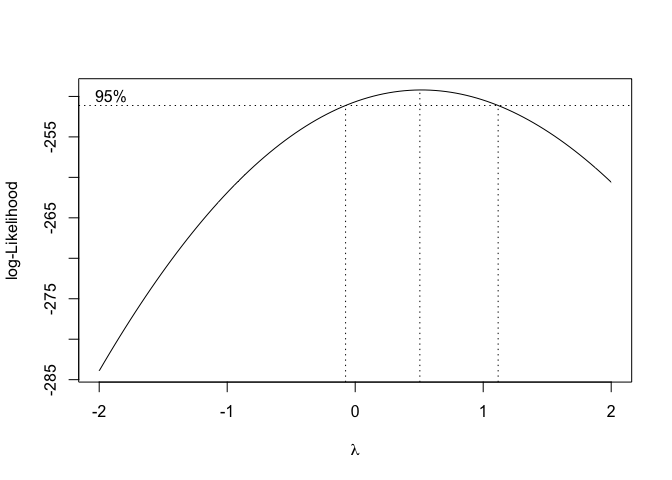

```r
boxcox(lm(log10(AQ_SessionsToAcquisition) ~ Strain, data = IVSA_resid))
```

This looks acceptable, though not ideal. Proceeding with model selection using the log10 transformation.

```r
AICs = c()
AICs["AIC_inter"] = AIC(lm(log10(AQ_SessionsToAcquisition) ~ Strain + Sex + Strain:Sex, data = IVSA_data))
AICs["AIC_nointer"] = AIC(lm(log10(AQ_SessionsToAcquisition)  ~ Strain + Sex, data = IVSA_data))
AICs["AIC_nosex"] = AIC(lm(log10(AQ_SessionsToAcquisition)  ~ Strain, data = IVSA_data))
AICs["AIC_nostrain"] = AIC(lm(log10(AQ_SessionsToAcquisition) ~ 1, data = IVSA_data))

AICs
```

```
##    AIC_inter  AIC_nointer    AIC_nosex AIC_nostrain
##    -4.667809   -16.828855   -16.201975    94.443165
```

```r
BICs = c()
BICs["BIC_inter"] = BIC(lm(log10(AQ_SessionsToAcquisition)  ~ Strain + Sex + Strain:Sex, data = IVSA_data))
BICs["BIC_nointer"] = BIC(lm(log10(AQ_SessionsToAcquisition)  ~ Strain + Sex, data = IVSA_data))
BICs["BIC_nosex"] = BIC(lm(log10(AQ_SessionsToAcquisition) ~ Strain, data = IVSA_data))
BICs["BIC_nostrain"] = BIC(lm(log10(AQ_SessionsToAcquisition) ~ 1, data = IVSA_data))

BICs
```

```
##    BIC_inter  BIC_nointer    BIC_nosex BIC_nostrain
##     52.79045     16.97012     14.21710    101.20296
```

```r
anova(lm(log10(AQ_SessionsToAcquisition) ~ Strain, data = IVSA_data))
```

|  | Df | Sum Sq | Mean Sq | F value | Pr(>F) |
| --- | --- | --- | --- | --- | --- |
| Strain | 7 | 8.422372 | 1.20319603 | 23.17115 | 3.891454e-23 |
| Residuals | 209 | 10.852631 | 0.05192646 | NA | NA |

```r
anova(lm(log10(AQ_SessionsToAcquisition) ~ Strain, data = IVSA_data))$`Pr(>F)`[1]
```

```
## [1] 3.891454e-23
```

### 2.3.5 Calculating heritability for sessions to acquisition

Calculating heritability using the ANOVA table from the best fitting model. Using the following equation:

$h^2=\displaystyle{{MS_{strain}}-{MS_{resid}}\over{MS_{strain} + (n_{mean} - 1) * MS_{resid}}}$

where $MS_{strain}$ is the mean square of the strain differences, $MS_{resid}$ is the mean square of the residuals, and $n_{mean}$ is the mean sample size of a strain.

Again, 129 has a ceiling effect, which would upwardly bias heritability calculations. Doing the calculation with and without 129.

```r
mean_n = nrow(IVSA_data) / length(unique(IVSA_data$Strain))
anova_AQ_SessionsToAcquisition = anova(lm(log10(AQ_SessionsToAcquisition) ~ Strain, data = IVSA_data))
anova_AQ_SessionsToAcquisition_df = as.data.frame(anova_AQ_SessionsToAcquisition)

h2_AQ_SessionsToAcquisition = h2_strainanova(anova_AQ_SessionsToAcquisition_df["Strain","Mean Sq"],
                                             anova_AQ_SessionsToAcquisition_df["Residuals","Mean Sq"],
                                             mean_n)

h2_AQ_SessionsToAcquisition
```

```
## [1] 0.4497542
```

This heritability of 0.45 is also higher than previous estimates.

Doing the calculation without 129.

```r
mean_n = nrow(IVSA_data_no_129) / length(unique(IVSA_data_no_129$Strain))
anova_AQ_SessionsToAcquisition_no_129 = anova(lm(log10(AQ_SessionsToAcquisition) ~ Strain, data = IVSA_data_no_129))
anova_AQ_SessionsToAcquisition_no_129_df = as.data.frame(anova_AQ_SessionsToAcquisition_no_129)
h2_AQ_SessionsToAcquisition_no_129 = h2_strainanova(anova_AQ_SessionsToAcquisition_no_129_df["Strain","Mean Sq"],
                                                    anova_AQ_SessionsToAcquisition_no_129_df["Residuals","Mean Sq"],
                                                    mean_n)
h2_AQ_SessionsToAcquisition_no_129
```

```
## [1] 0.3151773
```

This heritability of 0.32 is a good magnitude.

### 2.3.6 Plotting strain x sex means for sessions to acquisition

Plotting the strain:sex information for these data. The calculations will be back-transformed.

```r
IVSA_AQ_SessionsToAcquisition_summary = IVSA_data %>%
  group_by(Strain, Sex) %>%
  summarize(Strain_Sex_mean = mean(log10(AQ_SessionsToAcquisition), na.rm = TRUE),
            Strain_Sex_sem = sd(log10(AQ_SessionsToAcquisition), na.rm = TRUE) / length(which(!is.na(log10(AQ_SessionsToAcquisition)))),
            Strain_Sex_n = length(which(!is.na(log10(AQ_SessionsToAcquisition))))) %>%
  mutate(Strain_Sex = paste(Strain, gsub("^([MF]).*$", "\\1", Sex), sep = " "),
         Strain_Sex_backmean = 10 ^ Strain_Sex_mean,
         Strain_Sex_ul = 10 ^ (Strain_Sex_mean + Strain_Sex_sem),
         Strain_Sex_ll = 10 ^ (Strain_Sex_mean - Strain_Sex_sem))
```

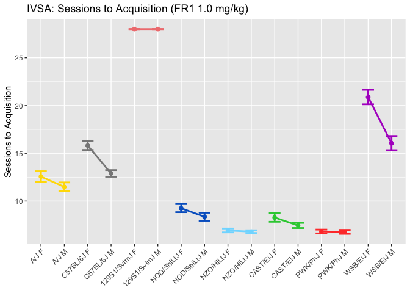

```r
IVSA_AQ_SessionsToAcquisition_summary = as.data.frame(IVSA_AQ_SessionsToAcquisition_summary)
IVSA_AQ_SessionsToAcquisition_summary$Strain_Sex = factor(IVSA_AQ_SessionsToAcquisition_summary$Strain_Sex,
                                                levels = paste(rep(founders_key$strain, each = 2), rep(c(" F", " M"), times = 8), sep = ""),
                                                ordered = TRUE)
IVSA_AQ_SessionsToAcquisition_summary$Strain = factor(IVSA_AQ_SessionsToAcquisition_summary$Strain,
                                            levels = founders_key$strain,
                                            ordered = TRUE)

IVSA_AQ_SessionsToAcquisition_plot = ggplot(data = IVSA_AQ_SessionsToAcquisition_summary, aes(x = Strain_Sex, y = Strain_Sex_backmean, color = Strain, group = Strain)) +
  geom_line(size = 1) +
  geom_point(size = 2) +
  geom_errorbar(aes(ymin = Strain_Sex_ll, ymax = Strain_Sex_ul), width = 0.5, size = 1) +
  scale_color_manual(values = founders_key$collaborative_cross_color_broman) +
  theme(axis.text.x = element_text(angle = 45, hjust = 1), legend.position="none") +
  xlab(NULL) +
  ylab("Sessions to Acquisition") +
  ggtitle("IVSA: Sessions to Acquisition (FR1 1.0 mg/kg)")

IVSA_AQ_SessionsToAcquisition_plot
```

Plotting individual points for IVSA infusions at FR-1 1.0 mg/kg

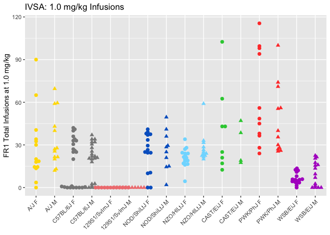

```r
IVSA_data$Strain_Sex = factor(paste(as.character(IVSA_data$Strain),
                                    as.character(IVSA_data$Sex),
                                    sep = " "),
                              levels = paste(rep(founders_key$strain, each = 2), rep(c("F","M"), times = 8), sep = " "),
                              ordered = TRUE)
IVSA_data$Strain = factor(IVSA_data$Strain, levels = founders_key$strain, ordered = TRUE)

founders_FR1_individual_points_plot = ggplot(data = IVSA_data, aes(x = Strain_Sex, y = DR_Inf_Total_1p0mgkg, color = Strain, shape = Sex)) +
  geom_beeswarm(size = 2) +
  scale_color_manual(values = c(founders_key$collaborative_cross_color_broman)) +
  scale_shape_manual(values = c(19,17)) +
  theme(axis.text.x = element_text(angle = 45, hjust = 1), legend.position="none") +
  xlab(NULL) +
  ylab("FR1 Total Infusions at 1.0 mg/kg") +
  ggtitle("IVSA: 1.0 mg/kg Infusions")
founders_FR1_individual_points_plot
```

Plotting individual points for IVSA sessions to acquisition

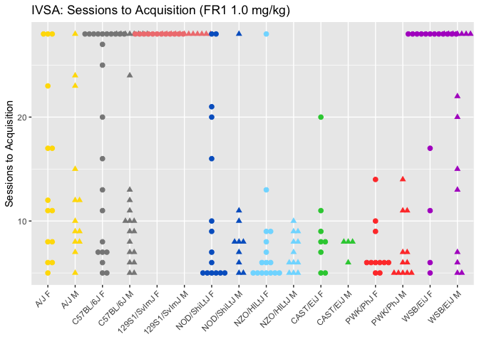

```r
founders_StA_individual_points_plot = ggplot(data = IVSA_data, aes(x = Strain_Sex, y = AQ_SessionsToAcquisition, color = Strain, shape = Sex)) +
  geom_beeswarm(size = 2) +
  scale_color_manual(values = c(founders_key$collaborative_cross_color_broman)) +
  scale_shape_manual(values = c(19,17)) +
  theme(axis.text.x = element_text(angle = 45, hjust = 1), legend.position="none") +
  xlab(NULL) +
  ylab("Sessions to Acquisition") +
  ggtitle("IVSA: Sessions to Acquisition (FR1 1.0 mg/kg)")
founders_StA_individual_points_plot
```

Saving plot

```r
saveRDS(IVSA_AQ_SessionsToAcquisition_plot, "./output/IVSA_AQ_SessionsToAcquisition_strain_sex_plot.RDS")
```

# 3 Reproducibility Information

## 3.1 Software Used

### 3.1.1 R session and OS information

```r
IVSA_sessionInfo
```

[output not shown]

```r
saveRDS(IVSA_sessionInfo, paste(script_root_dir, "./output/IVSA_sessionInfo_",current_date,".RDS", sep = ""), compress="xz")
```

## 3.2 Document Control

This document was prepared using RMarkdown in RStudio.